```r
#========================================================================================
# Load data
#========================================================================================

# Import health data
health_data <- read_csv("../Big City Data/Big City.csv")

# Import geo data
us_cities <- us_cities() %>%
  rename(City = "city",
         State = "state_abbr")



#========================================================================================
# Clean up data
#========================================================================================

health_data_tidy <- health_data %>%

  # Include all races and both genders
  filter(Sex == "Both",
         `Race/Ethnicity` == "All") %>%

  # Exclude unused columns
  select(-c(Indicator, `Shortened Indicator Name (Graph)`,
            `BCHC Requested Methodology`, Source, Methods,
            Notes, `90% Confidence Level - High`,
            `90% Confidence Level - Low`,
            `95% Confidence Level - High`,
            `95% Confidence Level - Low`)) %>%

  # Add a health category based on type
  mutate(Value = parse_number(Value),
         `Health Type` = case_when(
           `Shortened Indicator Name` %in% c("AIDS Diagnoses Rate",
                                             "All Types of Cancer Mortality Rate",
                                             "Asthma Emergency Department Visit Rate",
                                             "Death Rate (Overall)",
                                             "Diabetes Mortality Rate",
                                             "E.coli Infections",
                                             "Heart Disease Mortality Rate",
                                             "HIV-Related Mortality Rate",
                                             "HIV Diagnoses Rate",
                                             "Infant Mortality Rate",
                                             "Life Expectancy",
                                             "Low Birth Weight Babies",
                                             "Lung Cancer Mortality Rate",
                                             "Opioid-Related Overdose Mortality Rate",
                                             "Persons Living with HIV/AIDS Rate",
                                             "Pneumonia & Influenza Mortality Rate",
                                             "Salmonella Infections",
                                             "Tuberculosis Incidence Rate")               ~  "Disease Related",
           `Shortened Indicator Name` %in% c("Adult Binge Drinking",
                                             "Adult Obesity",
                                             "Adult Physical Activity Levels",
                                             "Adult Seasonal Flu Vaccine",
                                             "Adult Smoking",
                                             "Child Seasonal Flu Vaccine",
                                             "Pneumonia Vaccine (Age 65+)",
                                             "Population Uninsured",
                                             "Preschool Enrollment",
                                             "Teen Binge Drinking",
                                             "Teen Obesity",
                                             "Teen Physical Activity Levels",
                                             "Teen Smoking",
                                             "Unemployment")                              ~  "Personal Decisions",
           `Shortened Indicator Name` %in% c("200% Below the Poverty Level",
                                             "Adult Population",
                                             "Aging Population",
                                             "Child Poverty",
                                             "Children's Blood Lead Levels",
                                             "English Speaking Population",
                                             "Excessive Housing Cost Burden",
                                             "Firearm-Related ED Visit Rate",
                                             "Firearm-Related Mortality Rate",
                                             "Foreign Born Population",
                                             "High School Graduation",
                                             "Homicide Rate",
                                             "Median Household Income",
                                             "Motor Vehicle Mortality Rate",
                                             "Spanish Speaking Population",
                                             "Suicide Rate",
                                             "Teen Population",
                                             "Total Population",
                                             "Youth Population")                          ~  "Uncontrollable/Other"
         )) %>%

  # Split place into city and state
  separate(Place, into = c("City", "State"), sep = ", ") %>%

  # Split city farther to exclude extra information
  separate(City, into = c("City", "Location Description"), sep = " \\(") %>%

  # Fix San Diego County to be just San Diego
  mutate(City = case_when(
    City == "San Diego County"    ~  "San Diego",
    TRUE                          ~  City
  ))


#========================================================================================
# Join data
#========================================================================================

# Join health data with geo data
health_data_tidy_geo <- left_join(us_cities, health_data_tidy)

# Extract longitude and latitude from data
health_data_tidy_geo <- health_data_tidy_geo %>%
  filter(!is.na(`Indicator Category`)) %>%
  mutate(lon = map_dbl(geometry, ~st_centroid(.x)[[1]]),
         lat = map_dbl(geometry, ~st_centroid(.x)[[2]]))
```

# Final Project

## Background

**Is medical research making any difference to the number of people getting sick?**

Throughout the years there have been spectacular breakthroughs in many areas of study, including medicine. With all the time, energy, and money that has been spent on researching new medical practices and medications, is it making a significant impact? Have there been reductions in diseases and illnesses?

To learn more about the Big Cities Health Coalition click here.

## Data Exploration

In the first table show the different categories and sub-categories that are included in this data set. For many of my visualizations I decided to focus on those relating to diseases and illnesses. The second table shows a snippet of what the data looks like, including the categories and the values.

```r
datatable(health_data_tidy %>%
            select(`Indicator Category`, `Shortened Indicator Name`) %>%
            unique(), filter = "top", rownames = F,
          options = list(pageLength = 5),
          caption = "Table 1: Categories and subcategories included in data")
```

| Indicator Category | Shortened Indicator Name |
| --- | --- |
| Behavioral Health/Substance Abuse | Opioid-Related Overdose Mortality Rate |
| Behavioral Health/Substance Abuse | Adult Binge Drinking |
| Behavioral Health/Substance Abuse | Teen Binge Drinking |
| Cancer | All Types of Cancer Mortality Rate |
| Cancer | Lung Cancer Mortality Rate |
| Chronic Disease | Asthma Emergency Department Visit Rate |
| Chronic Disease | Diabetes Mortality Rate |
| Chronic Disease | Heart Disease Mortality Rate |
| Chronic Disease | Adult Obesity |
| Chronic Disease | Adult Smoking |

[output cut: 39 more lines]

```r
datatable(health_data_tidy %>%
            select(Year, City, `Shortened Indicator Name`, Value),
          filter = "top", rownames = F,
          options = list(pageLength = 5), caption = "Table 2: Preview of data used")
```

| Year | City | Shortened Indicator Name | Value |
| --- | --- | --- | --- |
| 2011 | Boston | Opioid-Related Overdose Mortality Rate | 3.9 |
| 2012 | Boston | Opioid-Related Overdose Mortality Rate | 3.6 |
| 2013 | Boston | Opioid-Related Overdose Mortality Rate | 4.4 |
| 2014 | Boston | Opioid-Related Overdose Mortality Rate | 9.9 |
| 2015 | Boston | Opioid-Related Overdose Mortality Rate | 15.4 |
| 2012 | Denver | Opioid-Related Overdose Mortality Rate | 5.5 |
| 2013 | Denver | Opioid-Related Overdose Mortality Rate | 6.3 |
| 2014 | Denver | Opioid-Related Overdose Mortality Rate | 8.8 |
| 2012 | Fort Worth | Opioid-Related Overdose Mortality Rate | 2.2 |
| 2013 | Fort Worth | Opioid-Related Overdose Mortality Rate | 1.1 |

[output cut: 3358 more lines]

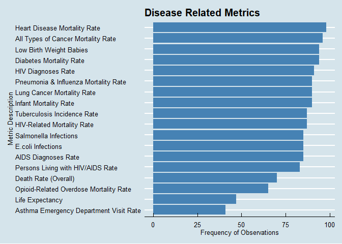

```r
health_data_tidy %>%
  filter(`Health Type` == "Disease Related") %>%
  group_by(`Shortened Indicator Name`) %>%
  summarise(Count = n()) %>%
  ggplot(aes(reorder(`Shortened Indicator Name`, Count), Count)) +
  geom_bar(stat = "identity", fill = "steelblue") +
  coord_flip() +
  labs(title = "Disease Related Metrics", x = "Metric Description",
       y = "Frequency of Observations") +
  theme_economist()
```

## Diseases and Illnesses

Below is a graph showing mortality rates for various illnesses across major cities in the United States. Cancer and heart disease is the leading cause of death in these categories. Looking over the years, though, there doesn’t seem to be much of a trend, for increasing or decreasing numbers. Some cities have more of a decrease than others, but the decrease is slight.

This is a density chart, the peaks show how many observations there are in each location. If the peaks moves to the right or left, that means the value over the years is either decreasing or increasing.

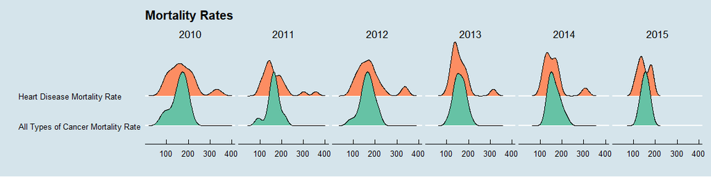

```r
# Disease related mortality rate

#health_data_tidy %>%
#  filter(`Health Type` == "Disease Related",
#         `Shortened Indicator Name` %in% c("All Types of Cancer Mortality Rate",
#                                           "Diabetes Mortality Rate",
#                                           "Heart Disease Mortality Rate",
#                                           "HIV-Related Mortality Rate",
#                                           "Infant Mortality Rate",
#                                           "Lung Cancer Mortality Rate",
#                                           "Opioid-Related Overdose Mortality Rate",
#                                           "Pneumonia & Influenza Mortality Rate"),
#         City != "U.S. Total") %>%
#  group_by(Year, `Shortened Indicator Name`, City, State) %>%
#  summarise(Value = mean(Value)) %>%
#  ggplot(aes(Year, Value, group = `Shortened Indicator Name`)) +
#  geom_line(aes(color = `Shortened Indicator Name`), size = 1.1) +
#  facet_wrap(~ City, scales = "free") +
#  theme_economist() +
#  scale_color_brewer(palette = "Set2") +
#  scale_x_continuous(breaks = seq(2010, 2016, by = 1)) +
#  labs(title = "Mortality Rates Across Cities", color = "", y = "Mortality Rate", x = "")



health_data_tidy %>%
  filter(`Health Type` == "Disease Related",
         `Shortened Indicator Name` %in% c("All Types of Cancer Mortality Rate",
                                           "Heart Disease Mortality Rate"),
         City != "U.S. Total") %>%
  ggplot(aes(Value, `Shortened Indicator Name`, fill = `Shortened Indicator Name`)) +
  geom_density_ridges() +
  theme_economist() +
  theme(legend.position = "none") +
  facet_grid(. ~ Year) +
  scale_fill_brewer(palette = "Set2") +
  labs(title = "Mortality Rates", color = "", y = "", x = "")
```

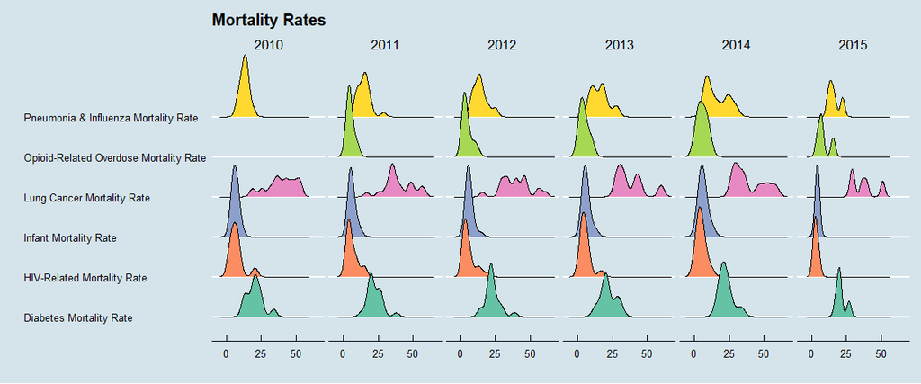

```r
health_data_tidy %>%
  filter(`Health Type` == "Disease Related",
         `Shortened Indicator Name` %in% c("Diabetes Mortality Rate",
                                           "HIV-Related Mortality Rate",
                                           "Infant Mortality Rate",
                                           "Lung Cancer Mortality Rate",
                                           "Opioid-Related Overdose Mortality Rate",
                                           "Pneumonia & Influenza Mortality Rate"),
         City != "U.S. Total") %>%
  ggplot(aes(Value, `Shortened Indicator Name`, fill = `Shortened Indicator Name`)) +
  geom_density_ridges() +
  theme_economist() +
  theme(legend.position = "none") +
  facet_grid(. ~ Year) +
  scale_fill_brewer(palette = "Set2") +
  labs(title = "Mortality Rates", color = "", y = "", x = "")
```

These next two graphs focus on pneumonia & influenza mortality rates as well as diabetes mortality rates. These categories are ones I felt fell in the category of diseases, but were ones that couldn’t necessarily be prevented completely by personal decisions and actions. They were also illnesses that should be treatable, to an extent.

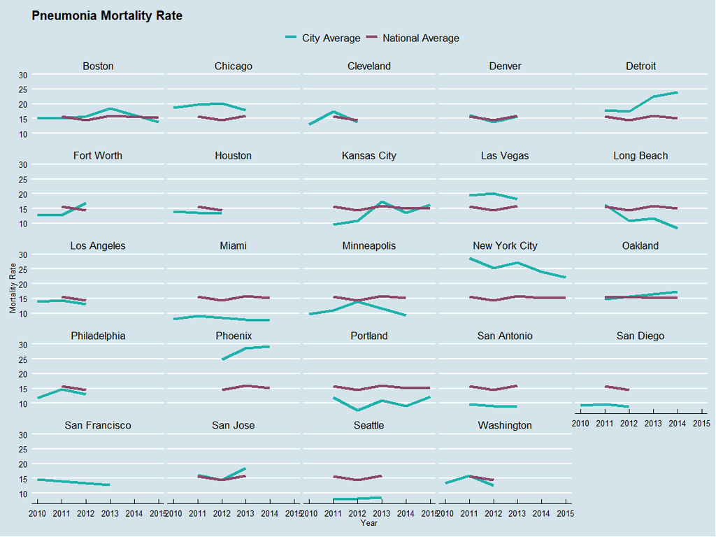

```r
# E.Coli and Pneumonia & Influenza Motrality Rate

Pneu_bench <- health_data_tidy %>%
  filter(City == "U.S. Total",
         `Shortened Indicator Name` == "Pneumonia & Influenza Mortality Rate") %>%
  select(Value, Year, `Shortened Indicator Name`) %>%
  rename("Pneumonia Benchmark" = Value)

health_data_tidy2 <- left_join(health_data_tidy, Pneu_bench)

health_data_tidy2 %>%
  filter(`Shortened Indicator Name` %in% c("Pneumonia & Influenza Mortality Rate"),
         City != "U.S. Total") %>%
  ggplot() +
  geom_line(aes(Year, Value, color = "City Average"), size = 1.5) +
  geom_line(aes(Year, `Pneumonia Benchmark`, color = "National Average"), size = 1.5) +
  theme_economist() +
  facet_wrap(~ City) +
  labs(title = "Pneumonia Mortality Rate", y = "Mortality Rate", color = "") +
  scale_x_continuous(breaks = seq(2010, 2016, by = 1)) +
  scale_y_continuous(breaks = seq(10, 30, by = 5)) +
  scale_color_manual(values = c("#20b2aa", "#8a496b"))
```

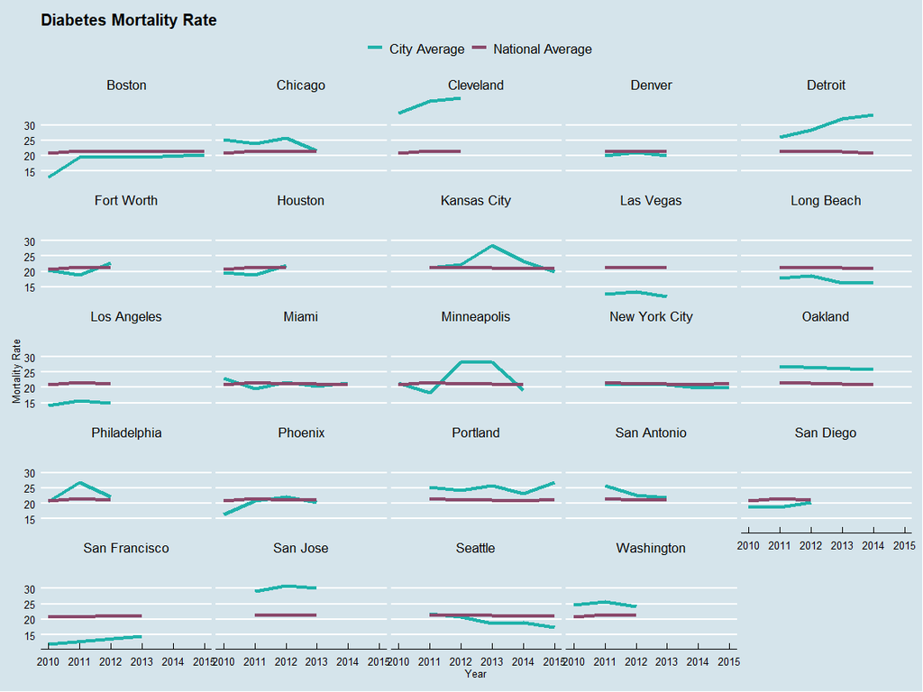

```r
Diab_bench <- health_data_tidy %>%
  filter(City == "U.S. Total",
         `Shortened Indicator Name` == "Diabetes Mortality Rate") %>%
  select(Value, Year, `Shortened Indicator Name`) %>%
  rename("Diabetes Benchmark" = Value)

health_data_tidy3 <- left_join(health_data_tidy, Diab_bench)


health_data_tidy3 %>%
  filter(`Shortened Indicator Name` %in% c("Diabetes Mortality Rate"),
         City != "U.S. Total") %>%
  ggplot() +
  geom_line(aes(Year, Value, color = "City Average"), size = 1.5) +
  geom_line(aes(Year, `Diabetes Benchmark`, color = "National Average"), size = 1.5) +
  theme_economist() +
  facet_wrap(~ City) +
  labs(title = "Diabetes Mortality Rate", y = "Mortality Rate", color = "") +
  scale_x_continuous(breaks = seq(2010, 2016, by = 1)) +
  scale_y_continuous(breaks = seq(10, 30, by = 5)) +
  scale_color_manual(values = c("#20b2aa", "#8a496b"))
```

The next two graphs focus on heart disease. This first graph is showing the mortality rate from heart disease in 2011 and 2013. The blue and red circles represent 2011 and 2013 respectively. Some cities didn’t have a value for both years. As you can see, many of the circles don’t have much of a size difference. There are some states that have a higher rate in 2011, but others who have had no improvement, and actually have a higher mortality rate in 2013, while others seem to have no difference at all.

```r
# Map of 2011 & 2013 heart disease

health_data_tidy_geo %>%
  leaflet() %>%
  setView(lng = -100, lat = 42.3601, zoom = 3) %>%
  addTiles() %>%
  addCircles(data = health_data_tidy_geo %>%
               filter(`Shortened Indicator Name` == "Heart Disease Mortality Rate",
                      Year == 2011), ~lon, ~lat,
             weight = 1, radius = ~Value*1000) %>%
  addCircles(data = health_data_tidy_geo %>%
               filter(`Shortened Indicator Name` == "Heart Disease Mortality Rate",
                      Year == 2013), ~lon, ~lat,
             weight = 1, radius = ~Value*1000, color = "red")
```

[interactive chart not shown]

This next graph still shows heart disease, but for all the years available. Here we can see more closely the trends in mortality rate and see that again, in some cities there are improvements, but some not. 14 of the 25 cities show a decrease.

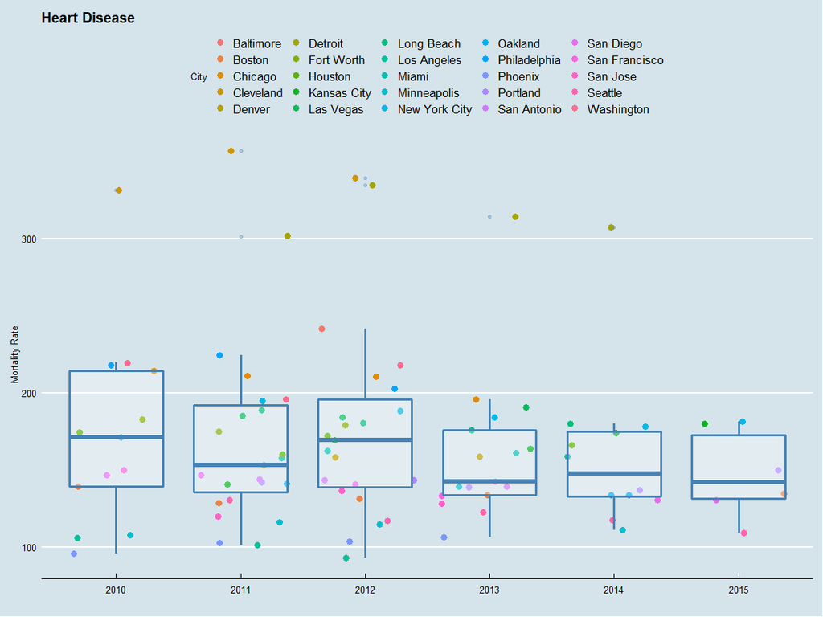

```r
# Heart disease mortality

#health_data_tidy_geo %>%
#  filter(`Shortened Indicator Name` == "Heart Disease Mortality Rate") %>%
#  ggplot(aes(Year, Value, color = City)) +
#  geom_line(size = 1.5) +
#  theme_economist() +
#  theme(legend.position = "none") +
#  facet_wrap(~ City, scales = "free") +
#  scale_x_continuous(breaks = seq(2010, 2016, by = 1)) +
#  labs(title = "Heart Disease", y = "Mortality Rate", x = "")


health_data_tidy_geo %>%
  filter(`Health Type` == "Disease Related",
         `Shortened Indicator Name` == "Heart Disease Mortality Rate") %>%
  mutate(Year = parse_character(Year)) %>%
  ggplot(aes(Year, Value, color = City)) +
  geom_jitter(size = 3) +
  geom_boxplot(size = 1.1, alpha = 0.3, color = "steelblue") +
  theme_economist() +
  #theme(legend.position = "none") +
  labs(title = "Heart Disease", y = "Mortality Rate", x = "")
```

```r
  #scale_color_brewer(palette = "Dark2")
```

## Personal Decisions

Below are shown some of the personal decisions people make in their lives that impact their health. Many diseases and illnesses aren’t treatable or preventable, but some are. These actions below, if they had a trend, could affect the trend in the diseases.

Looking below, though, there doesn’t seem to be a strong trend in these habits. Many stay constant.

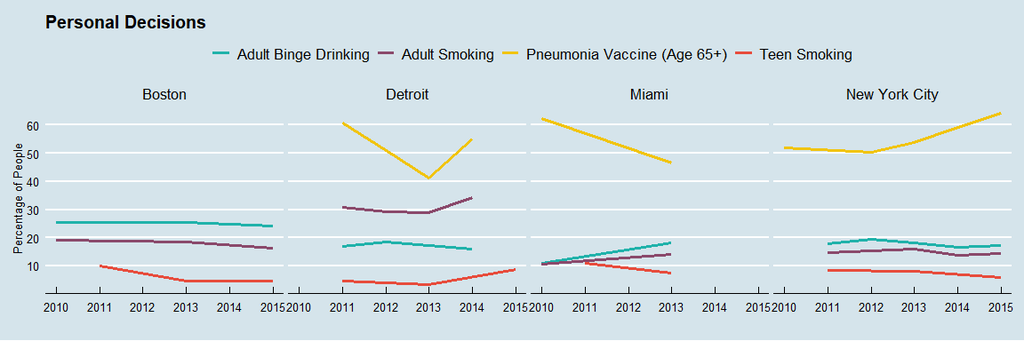

```r
health_data_tidy %>%
  filter(`Shortened Indicator Name` %in% c("Adult Binge Drinking",
                                           "Adult Smoking",
                                           "Teen Smoking",
                                           "Pneumonia Vaccine (Age 65+)"),
         City %in% c("Boston", "Detroit", "Miami", "New York City")) %>%
  ggplot(aes(Year, Value, color = `Shortened Indicator Name`)) +
  geom_line(size = 1.1) +
  facet_grid(. ~ City) +
  labs(title = "Personal Decisions", x = "", color = "",
       y = "Percentage of People") +
  theme_economist() +
  theme(legend.position = "top") +
  scale_x_continuous(breaks = seq(2010, 2016, by = 1)) +
  scale_y_continuous(breaks = seq(10, 60, by = 10)) +
  scale_color_manual(values = c("#20b2aa", "#8a496b", "#F1C40F", "#E74C3C"))
```

Comparing the percentage of people who get a pneumonia vaccine with the mortality rate there should be a negative correlation. The more people who get a vaccine, the lower the mortality rate. Unfortunately there doesn’t seem to be a correlation. Perhaps there isn’t enough data to show that, or the mortality rate is for all age groups whereas the vaccine percentage is only for those 65 and older.

This is a violin chart. The bubbling out of the shape indicates that there are more observations that fall into that category. If the bubbles widen or narrow across the years, then the mortality rates/percentages are increasing or decreasing respectively.

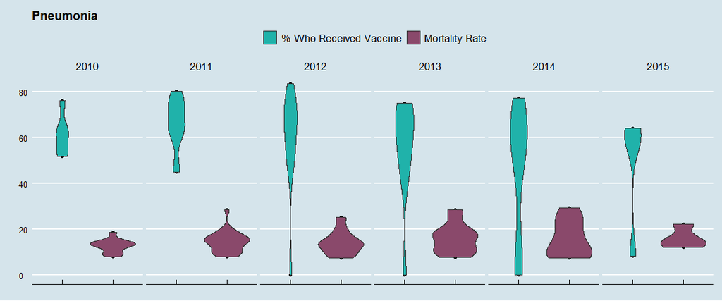

```r
#health_data_tidy %>%
#  filter(`Shortened Indicator Name` %in% c("Pneumonia & Influenza Mortality Rate",
#                                           "Pneumonia Vaccine (Age 65+)"),
#         City != "U.S. Total") %>%
#  ggplot(aes(Year, Value, color = `Shortened Indicator Name`)) +
#  geom_line(size = 1.1) +
#  facet_wrap(~ City, scales = "free") +
#  theme_economist() +
#  theme(legend.position = "top") +
#  labs(title = "Pneumonia", x = "", color = "") +
#  scale_color_manual(values = c("#20b2aa", "#8a496b")) +
#  scale_x_continuous(breaks = seq(2010, 2016, by = 1))

health_data_tidy %>%
  filter(`Shortened Indicator Name` %in% c("Pneumonia & Influenza Mortality Rate",
                                           "Pneumonia Vaccine (Age 65+)"),
         City != "U.S. Total") %>%
  mutate(`Shortened Indicator Name` = case_when(
    `Shortened Indicator Name` == "Pneumonia & Influenza Mortality Rate"  ~  "Mortality Rate",
    `Shortened Indicator Name` == "Pneumonia Vaccine (Age 65+)"  ~  "% Who Received Vaccine"
  )) %>%
  ggplot(aes(`Shortened Indicator Name`, Value, fill = `Shortened Indicator Name`)) +
  geom_point() +
  geom_violin() +
  theme_economist() +
  scale_fill_manual(values = c("#20b2aa", "#8a496b")) +
  scale_color_manual(values = c("#20b2aa", "#8a496b")) +
  facet_grid(. ~ Year) +
  theme(axis.text.x = element_blank()) +
  labs(title = "Pneumonia", x = "", fill = "", y = "")
```

## Conclusion

Based on the data, we can conclude that the mortality rate for diseases isn’t changing in significant ways. In some cities there are improvements, hopefully due to patients being treated more accurately based on research, but in other cities there are no improvements and sometimes even worsening. If I were to do further research I would look at the reasons why some of the cities are improving and find more data that shows diseases on a more granular scale.